# Relatório Municipal de Indicadores 2023

Mâncio Lima, Acre

SAGICAD e SNAS / MDS

# 1 ID CRAS: Indice de Desenvolvimento do CRAS

O ID CRAS é um indicador composto por três dimensões. Cada dimensão possui uma nota na qual quanto mais próxima de 5, melhor o índice e, do contrário, insatisfatório.

O Gráfico 1 mostra a evolução das médias do ID CRAS ao longo dos anos no município de Mâncio Lima, Acre.

Gráfico 1. Evolução das médias do ID CRAS, 2014 a 2023: Mâncio Lima, Acre

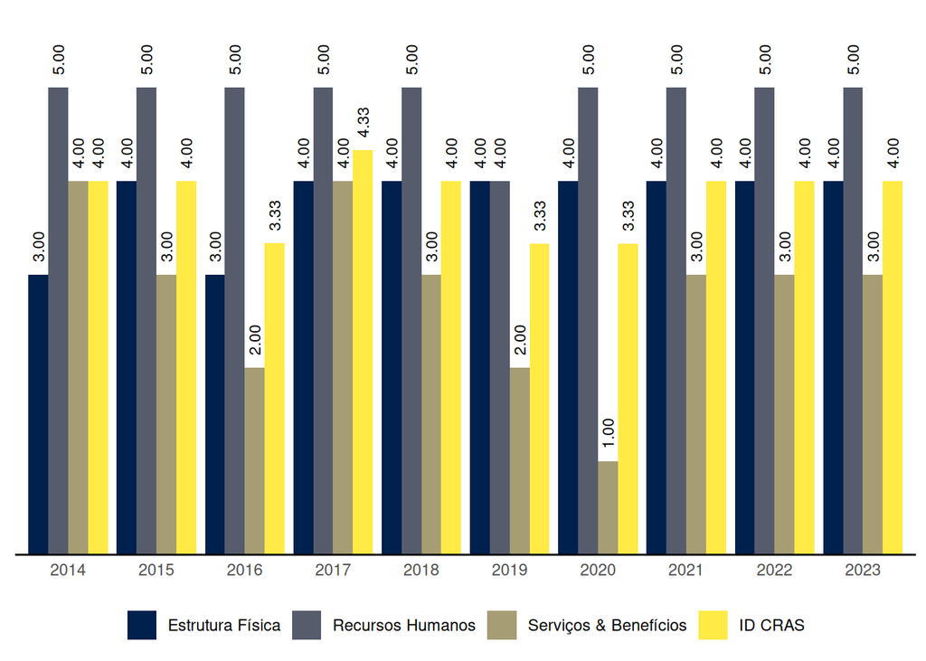

Tabela 1. Quantidade de CRAS em 2023 no município de Mâncio Lima por capacidade de referenciamento.

Quantidade de CRAS em 2023 no município de Mâncio Lima por capacidade de referenciamento.

| Capacidade de até: | Quantidade |
| --- | --- |
| 2.500 famílias referenciadas | 1 |
| 3.500 famílias referenciadas | 0 |
| 5.000 famílias referenciadas | 0 |

As seções a seguir apresentam os resultados do município de Mâncio Lima em cada uma das dimensões do ID CRAS, bem como os requisitos para se alcançar os níveis superiores.

## 1.1 ID CRAS: Dimensão Estrutura Física

### 1.1.1 CRAS com capacidade de referenciamento para até 2.500 ou 3.500 famílias

Na dimensão Estrutura Física, o nível de ID do CRAS com capacidade de referenciamento para até 2.500 ou 3.500 famílias no município de Mâncio Lima é 4.

O CRAS de **nível 4**, com capacidade de referenciamento para até 2.500 ou 3.500 famílias, na dimensão Estrutura Física:

- Possui **recepção**; e
- Possui no mínimo **2 salas de atendimento**, sendo **pelo menos 1 com capacidade para 15 ou mais pessoas**; e
- Possui no mínimo **2 banheiros**; e
- Possui **acessibiliadade, ao menos parcial**; e
- Possui **pelo menos 1 computador conectado à internet**.

Para alcançar o **nível 5** na dimensão Estrutura Física, o CRAS com capacidade de referenciamento para até 2.500 ou 3.500 famílias precisa, além dos requisitos do nível 4:

- Possuir no mínimo **1 sala administrativa**; e
- Possuir **acessibilidade**; e
- Possuir conjunto de equipamentos que inclua, no mínimo: **2 computadores conectados à internet, impressora, telefone e veículo exclusivo ou compartilhado**.

### 1.1.2 CRAS com capacidade de referenciamento para até 5.000 famílias

Mâncio Lima não tem CRAS com capacidade de referenciamento para até 5.000 famílias.

## 1.2 ID CRAS: Dimensão Recursos Humanos

### 1.2.1 CRAS com capacidade de referenciamento para até 2.500 famílias

Na dimensão Recursos Humanos, o nível de ID do CRAS com capacidade de referenciamento para até 2.500 famílias no município de Mâncio Lima é 5.

O CRAS de **nível 5**, com capacidade de referenciamento para até 2.500 famílias, na dimensão Recursos Humanos:

- Possui no mínimo **5** (9, se EV) **profissionais**, sendo pelo menos **3** (5, se EV) com **nível superior**; e
- Possui no mínimo **1 Assistente Social** (2, se EV) e **1 Psicólogo**; e
- Possui no mínimo **1** profissional de nível superior com **vínculo estatutário ou empregado público celetista**; e
- Possui **coordenador** com nível superior.

### 1.2.2 CRAS com capacidade de referenciamento para até 3.500 famílias

Mâncio Lima não tem CRAS com capacidade de referenciamento para até 3.500 famílias.

### 1.2.3 CRAS com capacidade de referenciamento para até 5.000 famílias

Mâncio Lima não tem CRAS com capacidade de referenciamento para até 5.000 famílias.

## 1.3 ID CRAS: Dimensão Serviços & Benefícios

Na dimensão Serviços & Benefícios, o nível de ID do CRAS no município de Mâncio Lima é 3.

O CRAS de **nível 3** na dimensão Serviços & Benefícios em município de porte Pequeno I:

- **Executa o PAIF** realizando no mínimo as seguintes atividades: **acompanhamento de famílias, grupo/oficina com famílias, visitas domiciliares e orientação/acompanhamento para inserção no BPC**; e
- Possui oferta de Serviço de Convivência **pelo menos para um ciclo de vida** (oferta direta do CRAS ou por meio de unidades a ele referenciadas); e
- Possui **forte articulação com os Serviços de Educação e Saúde** no território.

Para alcançar o **nível 4** na dimensão Serviços & Benefícios, o CRAS em município de porte Pequeno I precisa, além dos requisitos do nível 3:

- Ter **quantidade média de famílias em acompanhamento no mês, dividida pela equipe técnica** (Assistentes Sociais e Psicólogos) não inferior a 20 nem superior a 100; e
- **Executar o PAIF** realizando **palestras, campanhas ou eventos comunitários e acompanhamento dos encaminhamentos realizados**, além das atividades exigidas para o nível 3; e
- Possuir oferta de Serviço de Convivência **para no mínimo dois ciclos de vida** (oferta direta do CRAS ou por meio de unidades a ele referenciadas); e
- **Funcionar** no mínimo **5 dias** por semana e **40 horas** semanais.

# 2 ID CREAS: Indice de Desenvolvimento do CREAS

O ID CREAS é um indicador composto por três dimensões. Cada dimensão possui uma nota na qual quanto mais próxima de 5, melhor o índice e, do contrário, insatisfatório.

Mâncio Lima não tem CREAS.

# 3 ID Conselho: Indice de Desenvolvimento dos Conselhos de Assistência Social

O ID Conselho é indicador desenvolvimento com o objetivo de avaliar o controle social no SUAS. Ele possui três dimensões. Cada dimensão possui uma nota na qual quanto mais próxima de 5, melhor o índice e, do contrário, insatisfatório.

O Gráfico 2 mostra a evolução das médias do ID Conselho ao longo dos anos no município de Mâncio Lima, Acre.

Gráfico 2. Evolução das médias do ID Conselho, 2014 a 2023: Mâncio Lima, Acre

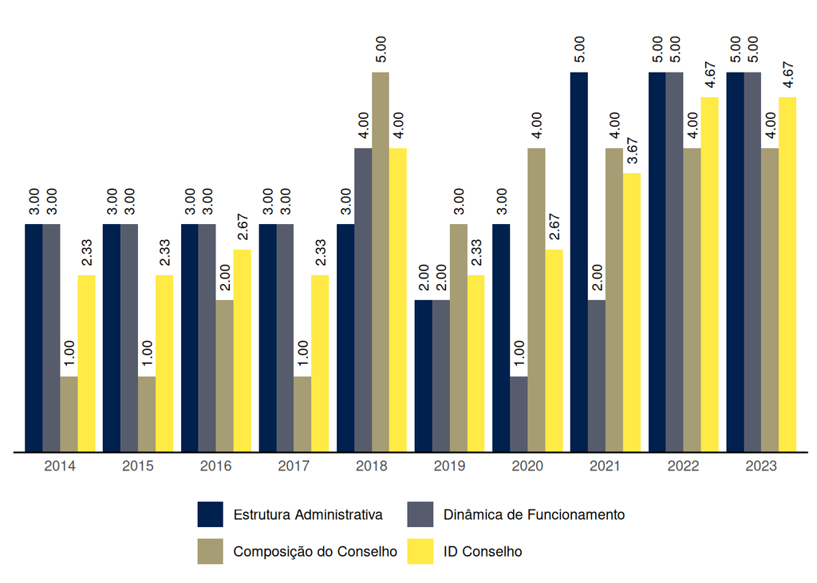

As seções a seguir apresentam os resultados do município de Mâncio Lima em cada uma das dimensões do ID Conselho, bem como os requisitos para se alcançar os níveis superiores.

## 3.1 ID Conselho: Dimensão Estrutura Administrativa

Na dimensão Estrutura Administrativa, o nível de ID do Conselho no município de Mâncio Lima é 5.

O Conselho de **nível 5** na dimensão Estrutura Administrativa em município de porte Pequeno I:

- Possui previsão de recursos específicos na Lei Orçamentária Anual; e
- Utiliza para as despesas de seu funcionamento o mínimo de 3% do IGD; e
- Possui uma ou mais salas de uso exclusivo; e
- Possui Secretaria Executiva; e
- Possui kit equipamento (veículo exclusivo ou compartilhado e um ou mais computadores conectados à internet); e
- Possui telefone de uso exclusivo ou compartilhado.

## 3.2 ID Conselho: Dimensão Dinâmica de Funcionamento

Na dimensão Dinâmica de Funcionamento, o nível de ID do Conselho no município de Mâncio Lima é 5.

O Conselho de **nível 5** na dimensão Dinâmica de Funcionamento em município de porte Pequeno I:

- Realizou 10 ou mais reuniões plenárias no ano anterior (ordinárias e extraordinárias); e
- Possui Regimento Interno; e
- Deliberou sobre o orçamento do executivo; e
- Deliberou sobre o Plano de Assistência Social; e
- É instância de Controle Social do Bolsa Família; e
- Acompanha o cumprimento de deliberações da Conferência Municipal; e
- Fiscaliza os serviços, programas e projetos da rede pública e privada (ou fiscaliza somente a rede pública quando não existe rede privada); e
- Realiza reuniões/ações de mobilização ou descentralizadas ou ampliadas.

## 3.3 ID Conselho: Dimensão Composição do Conselho

Na dimensão Composição do Conselho, o nível de ID do Conselho no município de Mâncio Lima é 4.

O Conselho de **nível 4** na dimensão Composição do Conselho em município de porte Pequeno I:

- Possui no mínimo 6 conselheiros titulares; e
- Possui representantes da sociedade civil eleitos por assembleias constituídas para esse fim; e
- Possui pelo menos um conselheiro titular representante de usuários ou organização de usuários; e
- Possui pelo menos um conselheiro titular representante de trabalhadores do setor; e
- Possui alternância na presidência entre os representantes de governo e os representantes da sociedade civil; e
- Possui Presidente e Vice-Presidente eleitos em plenária; e
- Permite que o Conselheiro possa ser reconduzido uma única vez.

Para alcançar o **nível 5** na dimensão Composição do Conselho, o Conselho em município de porte Pequeno I precisa, além dos requisitos do nível 4:

- Possuir no mínimo 8 conselheiros titulares; e
- Possuir representação governamental da área de assistência, saúde e educação.